# **Capstone project: Providing data-driven suggestions for HR**

## Description and deliverables

This capstone project is an opportunity for you to analyze a dataset and build predictive models that can provide insights to the Human Resources (HR) department of a large consulting firm.

Upon completion, you will have two artifacts that you would be able to present to future employers. One is a brief one-page summary of this project that you would present to external stakeholders as the data professional in Salifort Motors. The other is a complete code notebook provided here. Please consider your prior course work and select one way to achieve this given project question. Either use a regression model or machine learning model to predict whether or not an employee will leave the company. The exemplar following this actiivty shows both approaches, but you only need to do one.

In your deliverables, you will include the model evaluation (and interpretation if applicable), a data visualization(s) of your choice that is directly related to the question you ask, ethical considerations, and the resources you used to troubleshoot and find answers or solutions.

PACE stages

- Plan
- Analyze
- Construct
- Execute

# Pace: Plan Stage

- Understand your data in the problem context
- Consider how your data will best address the business need
- Contextualize & understand the data and the problem

🗒

### Understand the business scenario and problem

The HR department at Salifort Motors wants to take some initiatives to improve employee satisfaction levels at the company. They collected data from employees, but now they don’t know what to do with it. They refer to you as a data analytics professional and ask you to provide data-driven suggestions based on your understanding of the data. They have the following question: what’s likely to make the employee leave the company?

Your goals in this project are to analyze the data collected by the HR department and to build a model that predicts whether or not an employee will leave the company.

If you can predict employees likely to quit, it might be possible to identify factors that contribute to their leaving. Because it is time-consuming and expensive to find, interview, and hire new employees, increasing employee retention will be beneficial to the company.

### Familiarize yourself with the HR dataset

The dataset that you'll be using in this lab contains 15,000 rows and 10 columns for the variables listed below.

**Note:** you don't need to download any data to complete this lab. For more information about the data, refer to its source on [Kaggle](https://www.kaggle.com/datasets/mfaisalqureshi/hr-analytics-and-job-prediction?select=HR_comma_sep.csv).

| Variable | Description |  |
| --- | --- | --- |
| satisfaction_level | Employee-reported job satisfaction level [0–1] |  |
| last_evaluation | Score of employee's last performance review [0–1] |  |
| number_project | Number of projects employee contributes to |  |
| average_monthly_hours | Average number of hours employee worked per month |  |
| time_spend_company | How long the employee has been with the company (years) |  |
| Work_accident | Whether or not the employee experienced an accident while at work |  |
| left | Whether or not the employee left the company |  |
| promotion_last_5years | Whether or not the employee was promoted in the last 5 years |  |
| Department | The employee's department |  |
| salary | The employee's salary (U.S. dollars) |  |

💭

### Reflect on these questions as you complete the plan stage.

- Who are your stakeholders for this project?
- What are you trying to solve or accomplish?
- What are your initial observations when you explore the data?
- What resources do you find yourself using as you complete this stage? (Make sure to include the links.)
- Do you have any ethical considerations in this stage?

1. Stakeholders for this project is the HR department at Salifort Motors and company's senior leadership team.

2. The current high rate of turnover among Salifort employees that has been observed is the problem we are dealing with in this project. We will try to find and propose data-driven solution on how to improve employee satisfaction levels at the company and give the management the opportunity to predict employees likely to quit, or even to identify factors that contribute to their leaving. Since the procedure of finding, interviewing, and hiring new employees is time-consuming and expensive, increasing employee retention will be beneficial to the company.

3. We have a dataset with 15000 rows and 10 columns. There are both numerical and categorical variables. We have the "left" variable included that is going to be used as the target variable so we conclude that we have label data thus we will use the supervised ML classification techniques and methods.

4. The resources we used for this stage is the dataset from kaggle (https://www.kaggle.com/datasets/mfaisalqureshi/hr-analytics-and-job-prediction?select=HR_comma_sep.csv) and the information given in the "Description and deliverables" section of these assignment (https://www.coursera.org/learn/google-advanced-data-analytics-capstone/ungradedLab/uskOX/activity-course-7-salifort-motors-project-lab/lab?path=%2Fnotebooks%2FActivity_%2520Course%25207%2520Salifort%2520Motors%2520project%2520lab.ipynb) We also used python libraries pandas and seaborn, to load and manipulate the data and also visualise information.

5. We need to know if the information in the dataset is ethically acquired. This procedure need to be clear because the way it was performed may has resulted in introducing bias and unwanted false information in the dataset. We also need to check the "performance" variable and examine how it is calculated and if it is a fair process. Mistreatment or misjudjement of an employees performance can have great impact on the reasoning of quitting a job position. Finally we need to make sure that the inferences of our model will be used with caution and only in the benefit of an employee's status in the company. We need to make clear that a predictive model can and will have errors that have real-life concequences if applied without further consideration.

## Step 1. Imports

- Import packages
- Load dataset

### Import packages

```python
# Import packages
import pandas as pd
import numpy as np

import seaborn as sns
import matplotlib.pyplot as plt
```

### Load dataset

`Pandas` is used to read a dataset called **`HR_capstone_dataset.csv`.** As shown in this cell, the dataset has been automatically loaded in for you. You do not need to download the .csv file, or provide more code, in order to access the dataset and proceed with this lab. Please continue with this activity by completing the following instructions.

```python
# RUN THIS CELL TO IMPORT YOUR DATA.

# Load dataset into a dataframe
df0 = pd.read_csv("HR_capstone_dataset.csv")


# Display first few rows of the dataframe
df0.head()
```

|  | satisfaction_level | last_evaluation | number_project | average_montly_hours | time_spend_company | Work_accident | left | promotion_last_5years | Department | salary |
| --- | --- | --- | --- | --- | --- | --- | --- | --- | --- | --- |
| 0 | 0.38 | 0.53 | 2 | 157 | 3 | 0 | 1 | 0 | sales | low |
| 1 | 0.80 | 0.86 | 5 | 262 | 6 | 0 | 1 | 0 | sales | medium |
| 2 | 0.11 | 0.88 | 7 | 272 | 4 | 0 | 1 | 0 | sales | medium |
| 3 | 0.72 | 0.87 | 5 | 223 | 5 | 0 | 1 | 0 | sales | low |
| 4 | 0.37 | 0.52 | 2 | 159 | 3 | 0 | 1 | 0 | sales | low |

## Step 2. Data Exploration (Initial EDA and data cleaning)

- Understand your variables
- Clean your dataset (missing data, redundant data, outliers)

### Gather basic information about the data

```python
# Gather basic information about the data
df0.info()
```

```
<class 'pandas.core.frame.DataFrame'>
RangeIndex: 14999 entries, 0 to 14998
Data columns (total 10 columns):
 #   Column                 Non-Null Count  Dtype
---  ------                 --------------  -----
 0   satisfaction_level     14999 non-null  float64
 1   last_evaluation        14999 non-null  float64
 2   number_project         14999 non-null  int64
 3   average_montly_hours   14999 non-null  int64
 4   time_spend_company     14999 non-null  int64
 5   Work_accident          14999 non-null  int64
 6   left                   14999 non-null  int64
 7   promotion_last_5years  14999 non-null  int64
 8   Department             14999 non-null  object
 9   salary                 14999 non-null  object
dtypes: float64(2), int64(6), object(2)
memory usage: 1.1+ MB
```

### Gather descriptive statistics about the data

```python
# Gather descriptive statistics about the data
df0.describe(include="all")
```

|  | satisfaction_level | last_evaluation | number_project | average_montly_hours | time_spend_company | Work_accident | left | promotion_last_5years | Department | salary |
| --- | --- | --- | --- | --- | --- | --- | --- | --- | --- | --- |
| count | 14999.000000 | 14999.000000 | 14999.000000 | 14999.000000 | 14999.000000 | 14999.000000 | 14999.000000 | 14999.000000 | 14999 | 14999 |
| unique | NaN | NaN | NaN | NaN | NaN | NaN | NaN | NaN | 10 | 3 |
| top | NaN | NaN | NaN | NaN | NaN | NaN | NaN | NaN | sales | low |
| freq | NaN | NaN | NaN | NaN | NaN | NaN | NaN | NaN | 4140 | 7316 |
| mean | 0.612834 | 0.716102 | 3.803054 | 201.050337 | 3.498233 | 0.144610 | 0.238083 | 0.021268 | NaN | NaN |
| std | 0.248631 | 0.171169 | 1.232592 | 49.943099 | 1.460136 | 0.351719 | 0.425924 | 0.144281 | NaN | NaN |
| min | 0.090000 | 0.360000 | 2.000000 | 96.000000 | 2.000000 | 0.000000 | 0.000000 | 0.000000 | NaN | NaN |
| 25% | 0.440000 | 0.560000 | 3.000000 | 156.000000 | 3.000000 | 0.000000 | 0.000000 | 0.000000 | NaN | NaN |
| 50% | 0.640000 | 0.720000 | 4.000000 | 200.000000 | 3.000000 | 0.000000 | 0.000000 | 0.000000 | NaN | NaN |
| 75% | 0.820000 | 0.870000 | 5.000000 | 245.000000 | 4.000000 | 0.000000 | 0.000000 | 0.000000 | NaN | NaN |
| max | 1.000000 | 1.000000 | 7.000000 | 310.000000 | 10.000000 | 1.000000 | 1.000000 | 1.000000 | NaN | NaN |

### Rename columns

As a data cleaning step, rename the columns as needed. Standardize the column names so that they are all in `snake_case`, correct any column names that are misspelled, and make column names more concise as needed.

```python
# Display all column names
df0.columns
```

```
Index(['satisfaction_level', 'last_evaluation', 'number_project',
       'average_montly_hours', 'time_spend_company', 'Work_accident', 'left',
       'promotion_last_5years', 'Department', 'salary'],
      dtype='object')
```

```python
# Rename columns as needed
df0 = df0.rename(columns =
    {'satisfaction_level':'satisfaction',
        'last_evaluation':'performance',
        'number_project':'projects',
        'average_montly_hours':'monthly_hours',
        'time_spend_company':'tenure',
        'Work_accident':'accident',
        'left':'left',
        'promotion_last_5years':'promotion',
        'Department':'department',
        'salary':'salary'
    })


# Display all column names after the update
df0.columns
```

```
Index(['satisfaction', 'performance', 'projects', 'monthly_hours', 'tenure',
       'accident', 'left', 'promotion', 'department', 'salary'],
      dtype='object')
```

### Check missing values

Check for any missing values in the data.

```python
# Check for missing values
df0.isna().any(axis=1).sum()
```

```
0
```

### Check duplicates

Check for any duplicate entries in the data.

```python
# Check for duplicates
df0.duplicated()
```

```
0        False
1        False
2        False
3        False
4        False
         ...
14994     True
14995     True
14996     True
14997     True
14998     True
Length: 14999, dtype: bool
```

```python
# Inspect some rows containing duplicates as needed
### YOUR CODE HERE ###
df0[df0.duplicated()]
```

|  | satisfaction | performance | projects | monthly_hours | tenure | accident | left | promotion | department | salary |
| --- | --- | --- | --- | --- | --- | --- | --- | --- | --- | --- |
| 396 | 0.46 | 0.57 | 2 | 139 | 3 | 0 | 1 | 0 | sales | low |
| 866 | 0.41 | 0.46 | 2 | 128 | 3 | 0 | 1 | 0 | accounting | low |
| 1317 | 0.37 | 0.51 | 2 | 127 | 3 | 0 | 1 | 0 | sales | medium |
| 1368 | 0.41 | 0.52 | 2 | 132 | 3 | 0 | 1 | 0 | RandD | low |
| 1461 | 0.42 | 0.53 | 2 | 142 | 3 | 0 | 1 | 0 | sales | low |
| ... | ... | ... | ... | ... | ... | ... | ... | ... | ... | ... |
| 14994 | 0.40 | 0.57 | 2 | 151 | 3 | 0 | 1 | 0 | support | low |
| 14995 | 0.37 | 0.48 | 2 | 160 | 3 | 0 | 1 | 0 | support | low |
| 14996 | 0.37 | 0.53 | 2 | 143 | 3 | 0 | 1 | 0 | support | low |
| 14997 | 0.11 | 0.96 | 6 | 280 | 4 | 0 | 1 | 0 | support | low |
| 14998 | 0.37 | 0.52 | 2 | 158 | 3 | 0 | 1 | 0 | support | low |

3008 rows × 10 columns

```python
# Drop duplicates and save resulting dataframe in a new variable as needed
df = df0.drop_duplicates()


# Display first few rows of new dataframe as needed
df.head()
print(df.shape)
```

```
(11991, 10)
```

### Check outliers

Check for outliers in the data.

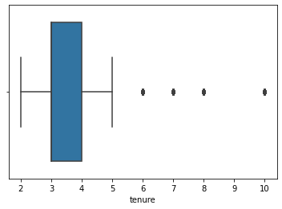

```python
# Create a boxplot to visualize distribution of `tenure` and detect any outliers
sns.boxplot(df['tenure'])
```

```python
# Determine the number of rows containing outliers
df[df['tenure'] > 5].count()
print(df.shape)

#Create a new df without outliers
#df_no = df[df['tenure'] <= 5]
#print(df_no.shape)
```

```
(11991, 10)
```

Certain types of models are more sensitive to outliers than others. When you get to the stage of building your model, consider whether to remove outliers, based on the type of model you decide to use.

# pAce: Analyze Stage

- Perform EDA (analyze relationships between variables)

💭

### Reflect on these questions as you complete the analyze stage.

- What did you observe about the relationships between variables?
- What do you observe about the distributions in the data?
- What transformations did you make with your data? Why did you choose to make those decisions?
- What are some purposes of EDA before constructing a predictive model?
- What resources do you find yourself using as you complete this stage? (Make sure to include the links.)
- Do you have any ethical considerations in this stage?

### What did you observe about the relationships between variables?

From the correlation heatmap we can see that performance, number of projects, average monthly hours, are the most correlated with each other, tenure and satisfaction also are correlated with other variables.

### What do you observe about the distributions in the data?

In performance evaluation we also see 2 peaks one at 0.5 and another wider in 0.8. This can mean that average performing employees left but high-performance employees also appear to be leaving the higher their performance is maybe because promotion rejection.

Number of projects also plays a role since we observed that the higher the projects the higher the probability of employee leaving. Additionally, in the lowest value of projects involved (2) we see high probability. There is an optimal value of number of projects which is 3.

Average monthly hours follows same distributions with satisfaction with an extend in higher values where every employee that worked in the extreme value has left the company.

We also see higher probability of leaving in the 5 year tenure employees.

Accident seems to be irrelevant with the results since there a not many employees that had accidents same with promotion. We can see that the higher the salary the lower the probability of an employee leaving.

Across department we see an equal probability distribution with lower values only in management and R&D departments

### What transformations did you make with your data? Why did you choose to make those decisions?

We transform the categorical data with One Hot Encoding method to numerical variables since all our models work better with numerical variables.

### What are some purposes of EDA before constructing a predictive model?

Clean the data. Check data type and validity Transform data to extract relevant and useful variables Check and remove missing values. Check and decide if needed to remove outliers. Check correlations between variables. Remove irrelevant variables of not significant importance.

### What resources do you find yourself using as you complete this stage? (Make sure to include the links.)

We used mainly pandas to analyse and seaborn libraries to plot investigating variables correlations and distributions.

### Do you have any ethical considerations in this stage?

As discussed in previous stage, we need to think if the variables available to us are valid , have been acquired with the correct methodology and if they are going to be available when the model is deployed.

## Step 2. Data Exploration (Continue EDA)

### Data visualizations

Now, start examining the variables that you're interested in, and create plots to visualize relationships between variables in the data.

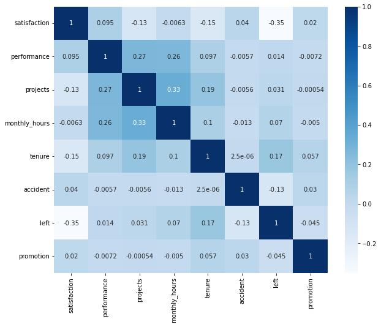

```python
fig = plt.subplots(figsize=(10,8))
sns.heatmap(df.corr(), cmap="Blues", annot=True)
plt.show()
```

[output not shown]

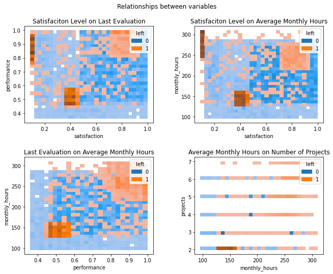

```python
#sns.pairplot(df)
fig, axes = plt.subplots(2,2,figsize=(10,8))

fig.suptitle('Relationships between variables')

axes[0,0].set_title('Satisfaciton Level on Last Evaluation')
axes[0,1].set_title('Satisfaciton Level on Average Monthly Hours')
axes[1,0].set_title('Last Evaluation on Average Monthly Hours')
axes[1,1].set_title('Average Monthly Hours on Number of Projects')

sns.histplot(data=df, x='satisfaction', y='performance', hue='left' ,ax=axes[0,0])
sns.histplot(data=df, x='satisfaction', y='monthly_hours', hue='left' ,ax=axes[0,1])
sns.histplot(data=df, x='performance', y='monthly_hours', hue='left' ,ax=axes[1,0])
sns.histplot(data=df, x='monthly_hours', y='projects', hue='left' ,ax=axes[1,1])

plt.tight_layout(pad=4, h_pad=2.0)
plt.show
```

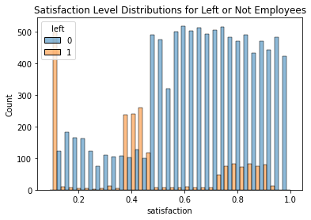

```python
# Create a plot as needed
fig, ax = plt.subplots()
plt.title('Satisfaction Level Distributions for Left or Not Employees')
sns.histplot(data=df, x='satisfaction', hue='left', multiple='dodge',alpha=0.5 , ax=ax)
fig.show()
```

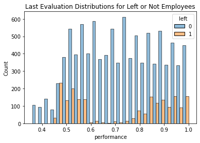

```python
# Create a plot as needed
fig, ax = plt.subplots()
plt.title('Last Evaluation Distributions for Left or Not Employees')
sns.histplot(data=df, x='performance', hue='left', multiple='dodge',alpha=0.5 , ax=ax)
fig.show()
```

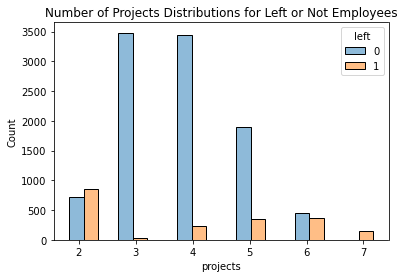

```python
# Create a plot as needed
fig, ax = plt.subplots()
plt.title('Number of Projects Distributions for Left or Not Employees')
sns.histplot(data=df, x='projects', hue='left', multiple='dodge',alpha=0.5 , ax=ax, shrink=3)
fig.show()
```

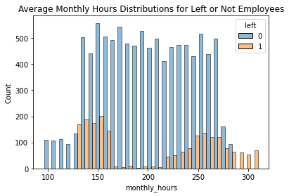

```python
# Create a plot as needed
fig, ax = plt.subplots()
plt.title('Average Monthly Hours Distributions for Left or Not Employees')
sns.histplot(data=df, x='monthly_hours', hue='left', multiple='dodge',alpha=0.5 , ax=ax)
fig.show()
```

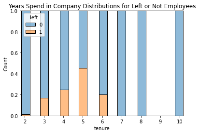

```python
# Create a plot as needed
fig, ax = plt.subplots()
plt.title('Years Spend in Company Distributions for Left or Not Employees')
sns.histplot(data=df, x='tenure', hue='left', multiple='fill',alpha=0.5 , ax=ax, shrink=5)
fig.show()
```

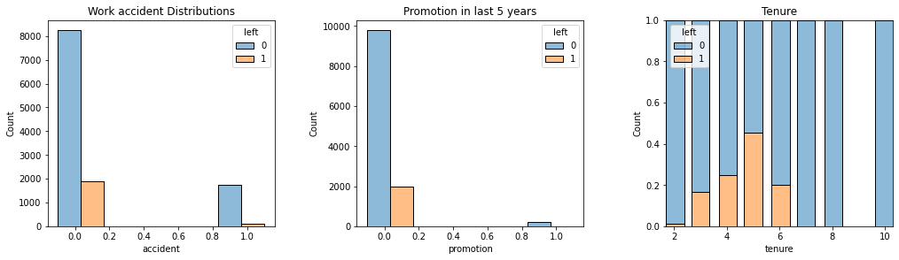

```python
# Create a plot as needed
fig, ax = plt.subplots(1,3, figsize=(15,5))

ax[0].set_title('Work accident Distributions')
sns.histplot(data=df, x='accident', hue='left', multiple='dodge',alpha=0.5 , ax=ax[0], shrink=4)

ax[1].set_title('Promotion in last 5 years')
sns.histplot(data=df, x='promotion', hue='left', multiple='dodge',alpha=0.5 , ax=ax[1], shrink=4)

ax[2].set_title('Tenure')
sns.histplot(data=df, x='tenure', hue='left',multiple='fill',alpha=0.5 , ax=ax[2], shrink=8)

plt.tight_layout(pad=4, h_pad=2.0)
fig.show()
```

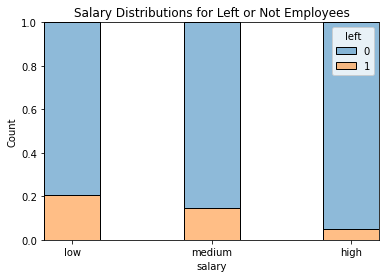

```python
# Create a plot as needed
fig, ax = plt.subplots()
plt.title('Salary Distributions for Left or Not Employees')
sns.histplot(data=df, x='salary', hue='left', multiple='fill',alpha=0.5 , ax=ax, shrink=0.4)
fig.show()
```

[figure not shown]

```python
# Create a plot as needed
fig, ax = plt.subplots()
plt.title('Salary Distributions for Left or Not Employees')
sns.histplot(data=df, x='department', hue='left', multiple='fill',alpha=0.5 , ax=ax, shrink=0.5)
#ax.set_xticks([0,1])
#ax.set_xticklabels([0,1])
plt.xticks(rotation = 45)
fig.show()
```

```python
df = pd.get_dummies(df)
df.info()
```

```
<class 'pandas.core.frame.DataFrame'>
Int64Index: 11991 entries, 0 to 11999
Data columns (total 21 columns):
 #   Column                  Non-Null Count  Dtype
---  ------                  --------------  -----
 0   satisfaction            11991 non-null  float64
 1   performance             11991 non-null  float64
 2   projects                11991 non-null  int64
 3   monthly_hours           11991 non-null  int64
 4   tenure                  11991 non-null  int64
 5   accident                11991 non-null  int64
 6   left                    11991 non-null  int64
 7   promotion               11991 non-null  int64
 8   department_IT           11991 non-null  uint8
 9   department_RandD        11991 non-null  uint8
 10  department_accounting   11991 non-null  uint8
 11  department_hr           11991 non-null  uint8
 12  department_management   11991 non-null  uint8
 13  department_marketing    11991 non-null  uint8
 14  department_product_mng  11991 non-null  uint8
 15  department_sales        11991 non-null  uint8
 16  department_support      11991 non-null  uint8
 17  department_technical    11991 non-null  uint8
 18  salary_high             11991 non-null  uint8
 19  salary_low              11991 non-null  uint8
 20  salary_medium           11991 non-null  uint8
dtypes: float64(2), int64(6), uint8(13)
memory usage: 1.2 MB
```

### Insights

There is a spike of high performance empoyees with low satisfaction levels leaving the company.

There is clear correlation between high rate of turnover among employees with higher average monthly hours (>250)

We see that the higher the salary the lower the probability of an employee leaving.

We observed that higher than 3 number of projects lead to employees leaving the company

Higher percentage of 5 year tenure employees leaving the company.

# paCe: Construct Stage

- Determine which models are most appropriate
- Construct the model
- Confirm model assumptions
- Evaluate model results to determine how well your model fits the data

🔎

## Recall model assumptions

**Logistic Regression model assumptions**

- Outcome variable is categorical
- Observations are independent of each other
- No severe multicollinearity among X variables
- No extreme outliers
- Linear relationship between each X variable and the logit of the outcome variable
- Sufficiently large sample size

# We are not going to use Logistic regression at his point

💭

### Reflect on these questions as you complete the constructing stage.

- Do you notice anything odd?
- Which independent variables did you choose for the model and why?
- Are each of the assumptions met?
- How well does your model fit the data?
- Can you improve it? Is there anything you would change about the model?
- What resources do you find yourself using as you complete this stage? (Make sure to include the links.)
- Do you have any ethical considerations in this stage?

### Do you notice anything odd?

In previous stage we identify the correlation between the variables and we selected the "left" column as the target predicted value. From the available columns only few appeared to have meaningful information. We decided to build simple Decition Tree Model and from that to extract the features with the highest importance to use in more advanced models later.

### Which independent variables did you choose for the model and why?

From the before mentined Decision Tree the results as expected where that satisfaction, performance, projects, monthly_hours, tenure and if salary is low are the most important features. To minimize computational capacity needed for the more advanced models we decided to keep only this features.

### Are each of the assumptions met?

Our Supervised ML methods do not have strict assumption we need to be aware of. Naive Bayes will use a Categorical algorithm which assumes all features are caterical and transform numerical data to such features. The independence among predictors and the equal power predictors assumptions may be violated but there is no need to focus on this matter since finally the more advanced models do not need to follow these rules.

### How well does your model fit the data?

The results were: Accuracy: 98.266% Precision: 98.690% Recall: 90.763% F1: 94.561%

### Can you improve it? Is there anything you would change about the model?

We have tried various model and fine tuned parameter so at this point the only way to improve the model is either with the addition of external new data, or with better feature engineering.

### What resources do you find yourself using as you complete this stage? (Make sure to include the links.)

We used mainly the sklearn library and the various classifiers and test modules available.

### Do you have any ethical considerations in this stage?

At this stage ethical considerations involce the correct interpretation of the results. Our model has very good results in precision, accuracy and f1 but the recall is lower than the other metrics. Recall is calculated from TP/(TP+FN) which mean that we have ~10% false negatives. This is when our model will predict that an employee is not going to leave the company(negative) but he will actually leave. This is very important to know that 10% of these situations cannont be predicted by our model. On the other hand, the insights provided here will help not only predict a similar situation but also improve the odds of such a situation never occur in the first place.

## Step 3. Model Building, Step 4. Results and Evaluation

- Fit a model that predicts the outcome variable using two or more independent variables
- Check model assumptions
- Evaluate the model

### Identify the type of prediction task.

We are dealing with labeled data and the target is a binary variable. We have features both categorical and numerical and these assumptions lead us to decide to use Supervised Machine Learning Classifiers methods and algorithms.

### Identify the types of models most appropriate for this task.

The options we have at this point are: Naive Bayes Classifiers, Decision Trees Classifiers, Random Forest Classifiers and XGBoost Classifiers

### Modeling

Add as many cells as you need to conduct the modeling process.

```python
#Initiate results table
results = pd.DataFrame(columns = ['Method','Accuracy','Precision','Recall','F1'])
columns_to_drop = ['left',
 'accident',
 'promotion',
 'department_IT',
 'department_RandD',
 'department_accounting',
 'department_hr',
 'department_management',
 'department_marketing',
 'department_product_mng',
 'department_sales',
 'department_support',
 'department_technical',
 'salary_high',
 'salary_medium']
```

```python
#imports
from sklearn.model_selection import train_test_split,GridSearchCV
from sklearn.metrics import recall_score, precision_score,accuracy_score,f1_score
from sklearn.metrics import ConfusionMatrixDisplay, confusion_matrix

#First Model
from sklearn import naive_bayes

#Second and Third Model
from sklearn.tree import DecisionTreeClassifier
from sklearn.tree import plot_tree

#Forth Model
from sklearn.ensemble import RandomForestClassifier

#Fifth Model
from xgboost import XGBClassifier
from xgboost import plot_importance
```

```python
#Useful functions
#Create result DataFrame for each model and append total results
def make_results(name,y_val,y_pred):
    '''
    Accepts as argument model object name, y data (train or validate), and y data predictions.
    Prints the scores.
    Returns a dictionary with the score for this model to be appended in the results table.
    '''
    accuracy_ = accuracy_score(y_val, y_pred)
    precision_ = precision_score(y_val, y_pred)
    recall_ = recall_score(y_val, y_pred)
    f1_ = f1_score(y_val, y_pred)

    # Print scores
    print(name)
    print(f'Accuracy  :{accuracy_:>8.3%}')
    print(f'Precision :{precision_:>8.3%}')
    print(f'Recall    :{recall_:>8.3%}')
    print(f'F1        :{f1_:>8.3%}')

    #Append scores to results table
    results_ = {
        'Method': name,
        'Accuracy': accuracy_,
        'Precision': precision_,
        'Recall': recall_,
        'F1': f1_
    }

    return results_


#Confusion Matrix function that will be used for all models
def conf_matrix_plot(model, x_data, y_data):
    '''
    Accepts as argument model object, X data (test or validate), and y data (test or validate).
    Returns a plot of confusion matrix for predictions on y data.
    '''
    model_pred = model.predict(x_data)
    cm = confusion_matrix(y_data, model_pred, labels=model.classes_)
    disp = ConfusionMatrixDisplay(confusion_matrix=cm,
                             display_labels=model.classes_)

    disp.plot()
    plt.show()
```

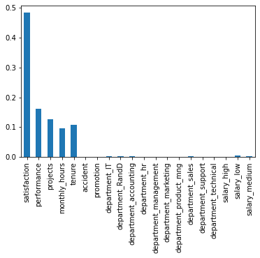

```python
#First of all we will create a decision tree model to validate
#our choice of features moving forward

#Split data in train and test sets
y = df['left']
X = df.copy()
X = X.drop('left', axis=1)

X_train, X_test, y_train, y_test = train_test_split(X, y, \
                                    test_size=0.25,stratify=y,random_state=15497)

#Initialise a Decision Tree Classifier
dtf = DecisionTreeClassifier(random_state=8461)

# Fit the model on training data
dtf.fit(X_train, y_train)

# Apply model to predict test data"
y_pred = dtf.predict(X_train)

#plot the tree
#plt.figure(figsize=(20,12))
#plot_tree(dtf, max_depth=2, fontsize=14, feature_names=X.columns)

#plot feature importances
importances = pd.Series(dtf.feature_importances_, index=X.columns)
fig, ax = plt.subplots()
importances.plot.bar(ax=ax)
```

```python
#Split data in train and test sets
y = df['left']
X = df.copy()
X = X.drop(columns_to_drop, axis=1)

#Create a train set and a test set(25%) stratified
#This will be the same for all the models since
#we need to have the same test subset
X_train, X_test, y_train, y_test = train_test_split(X, y, \
                                    test_size=0.25,stratify=y,random_state=64901)
```

```python
#Create a tr(ain) set and a validation set(20%) stratified
#This will be different for each model
X_tr, X_val, y_tr, y_val = train_test_split(X_train,y_train,\
                                    test_size=0.20,stratify=y_train,random_state=251)

#First we use Naive Bayes Categorical algorithm
nb = naive_bayes.CategoricalNB()

#Fit the model on your training data
nb.fit(X_tr, y_tr)

#Apply model to predict on validation data"
y_pred = nb.predict(X_val)

#Append results to results table
name = 'Naive Bayes Categorical'
results = results.append(make_results(name,y_val,y_pred),ignore_index=True)
```

```
Naive Bayes Categorical
Accuracy  : 91.329%
Precision : 73.754%
Recall    : 74.247%
F1        : 74.000%
```

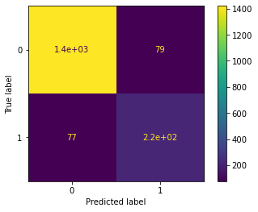

```python
#Display Confusion Matrix
conf_matrix_plot(nb, X_val, y_val)
```

```python
#Display Results
#results = results.drop(index=[1])
results.head(10)
```

|  | Method | Accuracy | Precision | Recall | F1 |
| --- | --- | --- | --- | --- | --- |
| 0 | Naive Bayes Categorical | 0.913285 | 0.737542 | 0.742475 | 0.74 |

```
Decision Tree
Accuracy  : 97.221%
Precision : 91.919%
Recall    : 91.304%
F1        : 91.611%
```

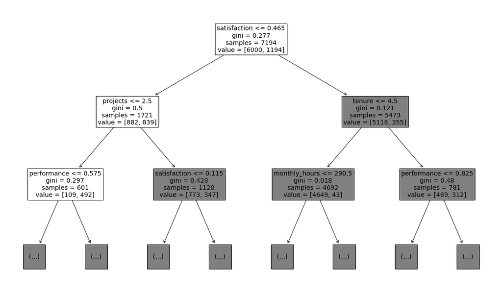

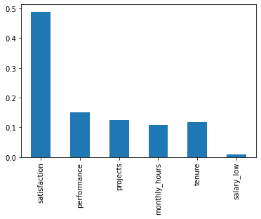

```python
#Create a tr(ain) set and a validation set(20%) stratified
#This will be different for each model
X_tr, X_val, y_tr, y_val = train_test_split(X_train,y_train,\
                                    test_size=0.20,stratify=y_train,random_state=9846)

#Second we use Decision Tree
dt = DecisionTreeClassifier(random_state=63145)

# Fit the model on your training data
dt.fit(X_tr, y_tr)

# Apply model to predict on validation data"
y_pred = dt.predict(X_val)

#Append results to results table
name = 'Decision Tree'
results = results.append(make_results(name,y_val,y_pred),ignore_index=True)

#plot the tree
plt.figure(figsize=(20,12))
plot_tree(dt, max_depth=2, fontsize=14, feature_names=X.columns)

#plot feature importances
importances = pd.Series(dt.feature_importances_, index=X.columns)
fig, ax = plt.subplots()
importances.plot.bar(ax=ax)
```

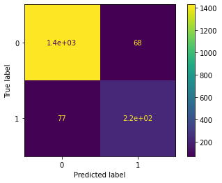

```python
#Display Confusion Matrix
conf_matrix_plot(nb, X_val, y_val)
```

```python
#Display results
#results = results.drop(index=[1,2,3,4])
results.head(10)
```

|  | Method | Accuracy | Precision | Recall | F1 |
| --- | --- | --- | --- | --- | --- |
| 0 | Naive Bayes Categorical | 0.913285 | 0.737542 | 0.742475 | 0.740000 |
| 1 | Decision Tree | 0.972207 | 0.919192 | 0.913043 | 0.916107 |

```
Decision Tree Tuned
Accuracy  : 98.388%
Precision : 96.233%
Recall    : 93.980%
F1        : 95.093%
```

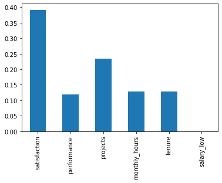

```python
#Create a tr(ain) set and a validation set(20%) stratified
#This will be different for each model
X_tr, X_val, y_tr, y_val = train_test_split(X_train,y_train,\
                                    test_size=0.20,stratify=y_train,random_state=895)

#Third we use Decision Tree Tuned
dtt = DecisionTreeClassifier(random_state=79451)

#Hyperparameters tuning config
cv_params = {'max_depth':[1,2,3,4,5,6,7,8,9,10,20,50],
             'min_samples_leaf': [2,3,4,5,6,7,8,9,10,15,20,50,100]}

scoring = {'accuracy', 'precision', 'recall', 'f1'}

#Cross validation Search
dtt_cv = GridSearchCV(dtt,
                   cv_params,
                   scoring = scoring,
                   cv=5,
                   refit="f1")

# Fit the model on your training data
dtt_cv.fit(X_tr,y_tr)

# Apply model to predict on validation data"
y_pred = dtt_cv.predict(X_val)

#Append results to results table
name = 'Decision Tree Tuned'
results = results.append(make_results(name,y_val,y_pred),ignore_index=True)

#plot feature importances
fimp = dtt_cv.best_estimator_.feature_importances_
importances = pd.Series(fimp, index=X.columns)
fig, ax = plt.subplots()
importances.plot.bar(ax=ax)
```

```python
#Show best parameters for the model
cv_results = pd.DataFrame(dtt_cv.cv_results_)
best_estimator_results = cv_results.iloc[cv_results['mean_test_f1'].idxmax(), :]
print(best_estimator_results.params)
```

```
{'max_depth': 8, 'min_samples_leaf': 2}
```

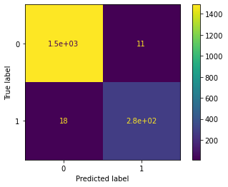

```python
#Display Confusion Matrix
conf_matrix_plot(dtt_cv, X_val, y_val)
```

```python
#Display Results
#results = results.drop(index=[3])
results.head(10)
```

|  | Method | Accuracy | Precision | Recall | F1 |
| --- | --- | --- | --- | --- | --- |
| 0 | Naive Bayes Categorical | 0.913285 | 0.737542 | 0.742475 | 0.740000 |
| 1 | Decision Tree | 0.972207 | 0.919192 | 0.913043 | 0.916107 |
| 2 | Decision Tree Tuned | 0.983880 | 0.962329 | 0.939799 | 0.950931 |

```python
#Create a tr(ain) set and a validation set(20%) stratified
#This will be different for each model
X_tr, X_val, y_tr, y_val = train_test_split(X_train,y_train,\
                                    test_size=0.20,stratify=y_train,random_state=4595)

#Forth we use Random Forest Classifier Tuned
rft = RandomForestClassifier(random_state=16901)

#Hyperparameters tuning
cv_params = {'n_estimators' : [15,25,50,75,100],
              'max_depth' : [3,5,10,25,50,75],
              'min_samples_leaf' : [0.5,1],
              'min_samples_split' : [0.001, 0.01],
              'max_features' : ["sqrt"],
              'max_samples' : [.5,.9]}

rft_cv = GridSearchCV(rft, cv_params, cv=5, refit='f1', n_jobs = -1, verbose = 4)
```

```python
%%time
# Fit the model.
rft_cv.fit(X_tr, y_tr)
```

```
Fitting 5 folds for each of 240 candidates, totalling 1200 fits
```

```
[Parallel(n_jobs=-1)]: Using backend LokyBackend with 2 concurrent workers.
[Parallel(n_jobs=-1)]: Done  21 tasks      | elapsed:    1.9s
[Parallel(n_jobs=-1)]: Done 272 tasks      | elapsed:   14.8s
[Parallel(n_jobs=-1)]: Done 764 tasks      | elapsed:   43.6s
[Parallel(n_jobs=-1)]: Done 1200 out of 1200 | elapsed:  1.2min finished
```

```
CPU times: user 1.64 s, sys: 164 ms, total: 1.8 s
Wall time: 1min 13s
```

[output not shown]

```
Random Forest Tuned
Accuracy  : 98.277%
Precision : 98.201%
Recall    : 91.304%
F1        : 94.627%
```

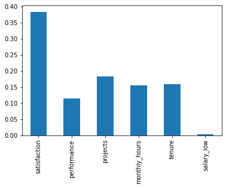

```python
# Apply model to predict on validation data"
y_pred = rft_cv.predict(X_val)

#Append results to results table
name = 'Random Forest Tuned'
results = results.append(make_results(name,y_val,y_pred),ignore_index=True)

#Display feature importance plot
fimp = rft_cv.best_estimator_.feature_importances_
importances = pd.Series(fimp, index=X.columns)
fig, ax = plt.subplots()
importances.plot.bar(ax=ax)
```

```python
#Show best parameters for the model
rft_cv.best_params_
```

```
{'max_depth': 25,
 'max_features': 'sqrt',
 'max_samples': 0.9,
 'min_samples_leaf': 1,
 'min_samples_split': 0.001,
 'n_estimators': 50}
```

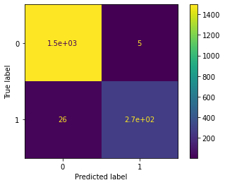

```python
#Display Confusion Matrix
conf_matrix_plot(rft_cv, X_val, y_val)
```

```python
#Display Results
#results = results.drop(index=[4])
results.head(10)
```

|  | Method | Accuracy | Precision | Recall | F1 |
| --- | --- | --- | --- | --- | --- |
| 0 | Naive Bayes Categorical | 0.913285 | 0.737542 | 0.742475 | 0.740000 |
| 1 | Decision Tree | 0.972207 | 0.919192 | 0.913043 | 0.916107 |
| 2 | Decision Tree Tuned | 0.983880 | 0.962329 | 0.939799 | 0.950931 |
| 3 | Random Forest Tuned | 0.982768 | 0.982014 | 0.913043 | 0.946274 |

```python
#Create a tr(ain) set and a validation set(20%) stratified
#This will be different for each model
X_tr, X_val, y_tr, y_val = train_test_split(X_train,y_train,\
                                    test_size=0.20,stratify=y_train,random_state=94618)

#Last, Five, we will use XGBoost method
#Initiate XGBoost classifier
xgb = XGBClassifier(objective='binary:logistic', random_state=894)

#Hyperparameters tuning
cv_params = {'max_depth': [2,3,4,5,6],
             'min_child_weight': [1,2,3,4],
             'learning_rate': [0.1, 0.2, 0.3],
             'n_estimators': [25,50,75,100]
             }

xgb_cv = GridSearchCV(xgb, cv_params, scoring=scoring, cv=5, refit='f1', n_jobs = -1, verbose = 4)
```

```python
%%time
#Fit the model
xgb_cv.fit(X_tr, y_tr)
```

```
Fitting 5 folds for each of 240 candidates, totalling 1200 fits
```

```
[Parallel(n_jobs=-1)]: Using backend LokyBackend with 2 concurrent workers.
[Parallel(n_jobs=-1)]: Done  21 tasks      | elapsed:    2.1s
[Parallel(n_jobs=-1)]: Done  94 tasks      | elapsed:    9.0s
[Parallel(n_jobs=-1)]: Done 217 tasks      | elapsed:   23.2s
[Parallel(n_jobs=-1)]: Done 388 tasks      | elapsed:   47.8s
[Parallel(n_jobs=-1)]: Done 609 tasks      | elapsed:  1.2min
[Parallel(n_jobs=-1)]: Done 878 tasks      | elapsed:  1.8min
[Parallel(n_jobs=-1)]: Done 1197 tasks      | elapsed:  2.5min
[Parallel(n_jobs=-1)]: Done 1200 out of 1200 | elapsed:  2.5min finished
```

```
CPU times: user 5.28 s, sys: 458 ms, total: 5.73 s
Wall time: 2min 29s
```

[output not shown]

```
XGBoost Tuned
Accuracy  : 98.444%
Precision : 97.880%
Recall    : 92.642%
F1        : 95.189%
```

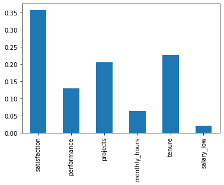

```python
#Predict values for test sample
y_pred = xgb_cv.predict(X_val)

#Append results to results table
name = 'XGBoost Tuned'
results = results.append(make_results(name,y_val,y_pred),ignore_index=True)

#Display feature importance plot
fimp = xgb_cv.best_estimator_.feature_importances_
importances = pd.Series(fimp, index=X.columns)
fig, ax = plt.subplots()
importances.plot.bar(ax=ax)
```

```python
#Show best parameters for the model
xgb_cv.best_params_
```

```
{'learning_rate': 0.1,
 'max_depth': 6,
 'min_child_weight': 1,
 'n_estimators': 75}
```

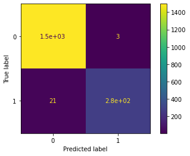

```python
#Display Confusion Matrix
conf_matrix_plot(rft_cv, X_val, y_val)
```

```python
#Display Results
#results = results.drop(index=[5,6,7,8,9])
results.head(10)
```

|  | Method | Accuracy | Precision | Recall | F1 |
| --- | --- | --- | --- | --- | --- |
| 0 | Naive Bayes Categorical | 0.913285 | 0.737542 | 0.742475 | 0.740000 |
| 1 | Decision Tree | 0.972207 | 0.919192 | 0.913043 | 0.916107 |
| 2 | Decision Tree Tuned | 0.983880 | 0.962329 | 0.939799 | 0.950931 |
| 3 | Random Forest Tuned | 0.982768 | 0.982014 | 0.913043 | 0.946274 |
| 4 | XGBoost Tuned | 0.984436 | 0.978799 | 0.926421 | 0.951890 |

```python
predictions = pd.DataFrame()
predictions['nb'] = nb.predict(X_test)
predictions['dt'] = dt.predict(X_test)
predictions['dtt_cv'] =dtt_cv.predict(X_test)
predictions['rft_cv'] =rft_cv.predict(X_test)
predictions['xgb_cv'] =xgb_cv.predict(X_test)
```

```python
#Display Results
#results = results.drop(index=[4,5,6,7])
models = ['nb','dt','dtt_cv','rft_cv','xgb_cv']
names = ['Naive Bayes Categorical - Test',
        'Decision Tree - Test',
        'Decision Tree Tuned - Test',
        'Random Forest Tuned - Test',
        'XGBoost Tuned - Test']

for i,model in enumerate(models):
    name = names[i]
    results = results.append(make_results(name,y_test,predictions[model]),ignore_index=True)

results.sort_values(by='Method',ignore_index=True)
```

```
Naive Bayes Categorical - Test
Accuracy  : 91.361%
Precision : 74.538%
Recall    : 72.892%
F1        : 73.706%
Decision Tree - Test
Accuracy  : 96.464%
Precision : 89.676%
Recall    : 88.956%
F1        : 89.315%
Decision Tree Tuned - Test
Accuracy  : 97.999%
Precision : 97.198%
Recall    : 90.562%
F1        : 93.763%
Random Forest Tuned - Test
Accuracy  : 98.165%
Precision : 98.681%
Recall    : 90.161%
F1        : 94.229%
XGBoost Tuned - Test
Accuracy  : 98.266%
Precision : 98.690%
Recall    : 90.763%
F1        : 94.561%
```

|  | Method | Accuracy | Precision | Recall | F1 |
| --- | --- | --- | --- | --- | --- |
| 0 | Decision Tree | 0.972207 | 0.919192 | 0.913043 | 0.916107 |
| 1 | Decision Tree - Test | 0.964643 | 0.896761 | 0.889558 | 0.893145 |
| 2 | Decision Tree Tuned | 0.983880 | 0.962329 | 0.939799 | 0.950931 |
| 3 | Decision Tree Tuned - Test | 0.979987 | 0.971983 | 0.905622 | 0.937630 |
| 4 | Naive Bayes Categorical | 0.913285 | 0.737542 | 0.742475 | 0.740000 |
| 5 | Naive Bayes Categorical - Test | 0.913609 | 0.745380 | 0.728916 | 0.737056 |
| 6 | Random Forest Tuned | 0.982768 | 0.982014 | 0.913043 | 0.946274 |
| 7 | Random Forest Tuned - Test | 0.981654 | 0.986813 | 0.901606 | 0.942288 |
| 8 | XGBoost Tuned | 0.984436 | 0.978799 | 0.926421 | 0.951890 |
| 9 | XGBoost Tuned - Test | 0.982655 | 0.986900 | 0.907631 | 0.945607 |

```python
#Pickle models in seperate files

import pickle

models = [nb,dt,dtt_cv,rft_cv,xgb_cv]
path = '/home/jovyan/work/'

for model in models:
    with open(path + type(model).__name__ + '.pkl','wb') as file:
        pickle.dump(model, file)
```

```python
#Use to load trained models from file
# for model in models:
#     with open(path + type(model).__name__ + '.pkl','rb') as file:
#          model = pickle.load(file)
```

# pacE: Execute Stage

- Interpret model performance and results
- Share actionable steps with stakeholders

✏

## Recall evaluation metrics

- **AUC** is the area under the ROC curve; it's also considered the probability that the model ranks a random positive example more highly than a random negative example.
- **Precision** measures the proportion of data points predicted as True that are actually True, in other words, the proportion of positive predictions that are true positives.
- **Recall** measures the proportion of data points that are predicted as True, out of all the data points that are actually True. In other words, it measures the proportion of positives that are correctly classified.
- **Accuracy** measures the proportion of data points that are correctly classified.
- **F1-score** is an aggregation of precision and recall.

💭

### Reflect on these questions as you complete the executing stage.

- What key insights emerged from your model(s)?
- What business recommendations do you propose based on the models built?
- What potential recommendations would you make to your manager/company?
- Do you think your model could be improved? Why or why not? How?
- Given what you know about the data and the models you were using, what other questions could you address for the team?
- What resources do you find yourself using as you complete this stage? (Make sure to include the links.)
- Do you have any ethical considerations in this stage?

### What key insights emerged from your model(s)?

Satisfaction level is the most important feature in the dataset and and play a vital role to the decision of an employee leaving or staying with the company. This is not the only important feature. Heavy workload (number of projects and average monthly hours) lack of promotions despite high performance evaluation and low salary tend to contribute to the final decision.

### What business recommendations do you propose based on the models built?

The company should prioritise the satisfaction of its employees and reduce workload when and if possible.

There is an optimal number of projects, 3, where after that value there is increased probability of an employee leave.

We observe also high turn rate after 4 years tenures. This can be due to the lack of promotions.

We see a clear correlation between high average monthly hours and high turn rate.

There is also high turn rate among employees with high performance evaluation again related probably to high monthly hours and lack of promotions.

### Do you think your model could be improved? Why or why not? How?

The model can be improved but the overall performance will not provide any additional benefit or insights from those acquired with these models. The key point is to implement changes in the employee management procedures and improve satisfaction.

### Given what you know about the data and the models you were using, what other questions could you address for the team?

We can discuss about what other feautures may be available from the company, or how we could feature engineer other more important and relevant that those already discussed.

### What resources do you find yourself using as you complete this stage? (Make sure to include the links.)

This stage is part of the stakeholder management where visualizations and descriptive stats are crucial to give those interest in the results of the project clear view about the models capabilities and restrictions.

### Do you have any ethical considerations in this stage?

At this stage we have concluded the model building evaluation and presentation to the stakeholders. We need to emphasise on the constrains of using such a model in predicting an employee decision and focus more on the insights of improving the features that the model recignised as the most important.

## Step 4. Results and Evaluation

- Interpret model
- Evaluate model performance using metrics
- Prepare results, visualizations, and actionable steps to share with stakeholders

### Summary of model results

XGBoost Tuned - Test Accuracy : 98.266% Precision : 98.690% Recall : 90.763% F1 : 94.561%

### Conclusion, Recommendations, Next Steps

The company should prioritise the satisfaction of its employees and reduce workload when and if possible.

There is an optimal number of projects, 3, where after that value there is increased probability of an employee leave.

We observe also high turn rate after 4 years tenures. This can be due to the lack of promotions.

We see a clear correlation between high average monthly hours and high turn rate.

There is also high turn rate among employees with high performance evaluation again related probably to high monthly hours and lack of promotions.